```python
import numpy as np
import matplotlib.pyplot as plt
```

# Fibonacci Numbers

In the Fibonacci sequence, each number $F_k$ is equal to the sum of the previous two: $F_k = F_{k-1}+F_{k-2}$. We typically start with $F_0=0$ and $F_1=1$ and compute forward from there. Direct application of the above definition will get us any arbitrary $F_k$, but we can also solve this problem by defining a dynamical system.

We define the state vector $\mathbf u_k = (F_{k+1}, F_k)$. Then we can write down the relationship

$$\mathbf u_{k+1} = \begin{bmatrix} 1&1 \\ 1&0 \end{bmatrix} \mathbf u_k.$$

If we diagonalize the matrix above, we find that the eigenvalues are $\lambda_1=\frac12(1+\sqrt5)$ and $\lambda_2=\frac12(1-\sqrt5)$ with corresponding eigenvectors $\mathbf x_1 = (\lambda_1,1)$ and $\mathbf x_2 = (\lambda_2,1)$. We can thus write down the explicit solution for $\mathbf u_k$:

$$\mathbf u_k = \begin{bmatrix} \lambda_1 & \lambda_2 \\ 1&1 \end{bmatrix} \begin{bmatrix} \lambda_1^k & 0 \\ 0 & \lambda_2^k \end{bmatrix} \begin{bmatrix} \lambda_1 & \lambda_2 \\ 1&1 \end{bmatrix}^{-1} \mathbf u_0 = \frac{\lambda_1^k}{\lambda_1-\lambda_2} \begin{bmatrix} \lambda_1 \\ 1 \end{bmatrix} - \frac{\lambda_2^k}{\lambda_1-\lambda_2} \begin{bmatrix} \lambda_2 \\ 1 \end{bmatrix}$$

We can now find any Fibonacci number by evaluating the second row of the equation above. For example,

$$F_{100} = \frac{\lambda_1^{100} - \lambda_2^{100}}{\lambda_1-\lambda_2} \approx 3.5422 \times 10^{20}.$$

Note that $|\lambda_2| < 1$; as $k \rightarrow \infty$, $\lambda_2^k \rightarrow 0$. $\lambda_1$ is called a *dominant eigenvalue* and is also referred as the *golden ratio* in the context of Fibonacci numbers. We can also make the following observations for sufficiently large $k$:

- $\mathbf u_{k+1} \approx \lambda_1 \mathbf u_k$
- $F_{k+1} \approx \lambda_1 F_k$
- $F_k \approx \lambda_1^k/(\lambda_1-\lambda_2)$

```python
A = np.array([[1,1],[1,0]])
L, X = np.linalg.eig(A)
print(L)
```

```
[ 1.61803399 -0.61803399]
```

```
u20 =  [10946.  6765.]
```

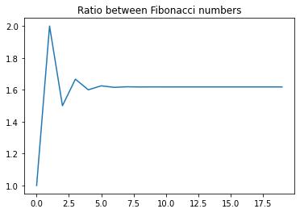

```python
# Fibonacci numbers
# uk = (Fk+1, Fk)

A = np.array([[1,1],[1,0]])
L, X = np.linalg.eig(A)
u0 = np.array([1,0])
c = np.linalg.inv(X) @ u0

# Compute kth Fibonacci number without matrix multiplication
k = 20
uk = c[0] * L[0]**k * X[:,0] + c[1] * L[1]**k * X[:,1]
print("u20 = ", uk)

# Show convergence to golden ratio (first eigenvalue)
ratio = np.zeros(k)
u = u0
for i in range(k):
  u = A @ u
  ratio[i] = u[0]/u[1]

plt.plot(ratio)
plt.title('Ratio between Fibonacci numbers')
plt.show()
```

# Population Modeling

A dynamical system can be used to model changes in a population over time. We divide the population of interest into $n$ age classes (e.g., ages 0-10, 10-20, etc.). The state vector $\mathbf u_k$ is thus an $n$-vector representing the population of each class at time $k$. We may also have two sets of parameters: $f_i$ represents the *fecundity* (average number of offspring per capita) of class $i$, and $s_i$ represents the *survival rate* of class $i$. The dynamical system can then be defined by the **Leslie matrix** $A$:

$$\mathbf u_{k+1} = A \mathbf u_k = \begin{bmatrix} f_1 & f_2 & \cdots & f_{n-1} & f_n \\ s_1 & 0 & \cdots & 0 & 0 \\ 0 & s_2 & \cdots & 0 & 0 \\ 0 & 0 & \ddots & \vdots & \vdots \\ 0 & 0 & \cdots & s_{n-1} & 0 \end{bmatrix} \mathbf u_k$$

Once again, the eigenvalues of $A$ tell us the story. If there is at least one eigenvalue magnitude larger than 1, the population will grow. In this case, we can also say that the largest eigenvalue forms the asymptotic *growth rate*, and the corresponding eigenvector is the asymptotic population ratio.

If all eigenvalues have magnitude less than 1, the entire population will eventually die off over time. As in the growth case, the largest eigenvalue will be the asymptotic *decay rate*, and the correspondng eigenvector is the asymptotic population ratio.

```
L =  [ 1.06253793 -1.01417116 -0.00836678]
X =
 [[-6.33924954e-01  6.08339605e-01  7.76398245e-05]
 [-5.84681671e-01 -5.87842406e-01 -9.09394695e-03]
 [-5.06247466e-01  5.33258129e-01  9.99958646e-01]]
```

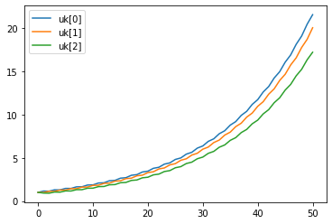

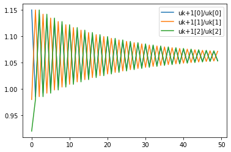

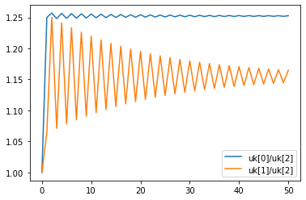

```python
# Population growth
# uk = (n1, n2, n3) = (young, middle-aged, elderly)
# Reproduction: n1_k+1 = F1 n1_k + F2 n2_k + F3 n3_k
# Survivabiity: n2_k+1 = P1 n1_k, n3_k+1 = P2 n2_k

A = np.array([[.04, 1.1, .01],
              [.98, 0, 0],
              [0, .92, 0]])

# Largest eigenvalue determines growth rate
# Corresponding eigenvector is steady state population ratio
L, X = np.linalg.eig(A)
print("L = ", L)
print("X = \n", X)

# Simulate population growth over time
u0 = np.array([1,1,1])
k = 50
pop = np.zeros((k+1,3))
pop[0,:] = u0

for i in range(k):
  pop[i+1,:] = A @ pop[i,:]

plt.plot(pop)
plt.legend(['uk[0]', 'uk[1]', 'uk[2]'])
plt.figure()
plt.plot(pop[1:,:]/pop[0:k,:])
plt.legend(['uk+1[0]/uk[0]', 'uk+1[1]/uk[1]', 'uk+1[2]/uk[2]'])
plt.figure()
plt.plot(range(k+1), pop[:,0]/pop[:,2], range(k+1), pop[:,1]/pop[:,2])
plt.legend(['uk[0]/uk[2]', 'uk[1]/uk[2]'])
plt.show()
```

```
L =  [ 0.8975747  -0.84606572 -0.01150898]
X =
 [[-5.50721469e-01  5.16292137e-01  1.51540266e-04]
 [-5.82887861e-01 -5.79715639e-01 -1.25087790e-02]
 [-5.97450923e-01  6.30374656e-01  9.99921751e-01]]
```

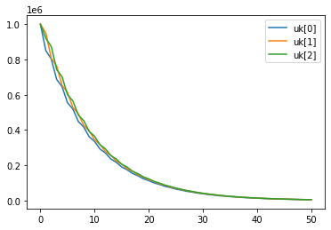

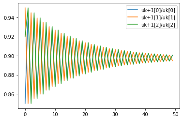

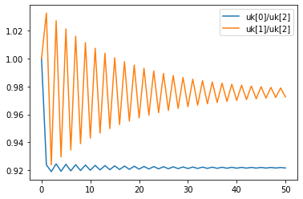

```python
# Population decline
A = np.array([[.04, .8, .01],
              [.95, 0, 0],
              [0, .92, 0]])
L, X = np.linalg.eig(A)
print("L = ", L)
print("X = \n", X)

u0 = 10**4*np.array([100,100,100])
k = 50
pop = np.zeros((k+1,3))
pop[0,:] = u0

for i in range(k):
  pop[i+1,:] = A @ pop[i,:]

plt.plot(pop)
plt.legend(['uk[0]', 'uk[1]', 'uk[2]'])
plt.figure()
plt.plot(pop[1:,:]/pop[0:k,:])
plt.legend(['uk+1[0]/uk[0]', 'uk+1[1]/uk[1]', 'uk+1[2]/uk[2]'])
plt.figure()
plt.plot(range(k+1), pop[:,0]/pop[:,2], range(k+1), pop[:,1]/pop[:,2])
plt.legend(['uk[0]/uk[2]', 'uk[1]/uk[2]'])
plt.show()
```